# Test a Perceptual Phenomenon

### Analyzing the Stroop Effect

Perform the analysis in the space below. Remember to follow [the instructions](https://docs.google.com/document/d/1-OkpZLjG_kX9J6LIQ5IltsqMzVWjh36QpnP2RYpVdPU/pub?embedded=True) and review the [project rubric](https://review.udacity.com/#!/rubrics/71/view) before submitting. Once you've completed the analysis and write-up, download this file as a PDF or HTML file, upload that PDF/HTML into the workspace here (click on the orange Jupyter icon in the upper left then Upload), then use the Submit Project button at the bottom of this page. This will create a zip file containing both this .ipynb doc and the PDF/HTML doc that will be submitted for your project.

```python
import math
import pandas as pd
import numpy as np
import seaborn as sns
from scipy.stats import t as pt
import matplotlib.pyplot as plt
%matplotlib inline
```

```python
df = pd.read_csv('./stroopdata.csv')
df.head()
```

|  | Congruent | Incongruent |
| --- | --- | --- |
| 0 | 12.079 | 19.278 |
| 1 | 16.791 | 18.741 |
| 2 | 9.564 | 21.214 |
| 3 | 8.630 | 15.687 |
| 4 | 14.669 | 22.803 |

(1) What is the independent variable? What is the dependent variable?

> - **`Independent variable:`** Congruent or Incongruent condition.
> - **`Dependent variable:`** Time to complete test.

(2) What is an appropriate set of hypotheses for this task? Specify your null and alternative hypotheses, and clearly define any notation used. Justify your choices.

> For this hypothesis, we could ask "Are the congruent and incongruent populations the same? Or do they differ?". Therefore, the notation is as follows: **Hypothesis**
> - $H_{0}$ : $μ_{C} - μ_{1}$ = ${0}$
> - $H_{1}$ : $μ_{C} - μ_{1}$ ≠ ${0}$

> The null of our hypothesis is that $μ_{C}$ (congruent mean) minus $μ_{1}$ (incongruent mean) is equal to 0, and the alternative is $μ_{C}$ (congruent) minus $μ_{1}$ (incongruent) is not equal to zero.

> The Dependent Samples t-Test is the appropriate statistical test as the same subjects are assigned two different conditions. The different conditions are dependent because, in theory, by doing the first test you have some practice doing it and you might have an unfair advantage due to this learning effect in doing the similar type of test second. In addition, we don't have any population parameters provided (so a z-test would not be appropriate here).

(3) Report some descriptive statistics regarding this dataset. Include at least one measure of central tendency and at least one measure of variability. The name of the data file is 'stroopdata.csv'.

```python
df.describe()
```

|  | Congruent | Incongruent |
| --- | --- | --- |
| count | 24.000000 | 24.000000 |
| mean | 14.051125 | 22.015917 |
| std | 3.559358 | 4.797057 |
| min | 8.630000 | 15.687000 |
| 25% | 11.895250 | 18.716750 |
| 50% | 14.356500 | 21.017500 |
| 75% | 16.200750 | 24.051500 |
| max | 22.328000 | 35.255000 |

```python
df.info()
```

```
<class 'pandas.core.frame.DataFrame'>
RangeIndex: 24 entries, 0 to 23
Data columns (total 2 columns):
Congruent      24 non-null float64
Incongruent    24 non-null float64
dtypes: float64(2)
memory usage: 464.0 bytes
```

```python
df.shape
```

```
(24, 2)
```

```python
con = df['Congruent']; incon = df['Incongruent']
```

```python
# get the mean for Congruent
con_mean = con.mean(); round(con_mean,2)
```

```
14.050000000000001
```

```python
# get the mean for Incongruent
incon_mean = incon.mean(); round(incon_mean,2)
```

```
22.02
```

```python
# get the standard deviation for Congruent
con_sd = con.std(); round(con_sd,2)
```

```
3.5600000000000001
```

```python
# get the standard deviation for incongruent
incon_sd = incon.std(); round(incon_sd,2)
```

```
4.7999999999999998
```

(4) Provide one or two visualizations that show the distribution of the sample data. Write one or two sentences noting what you observe about the plot or plots.

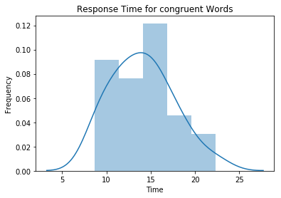

```python
sns.distplot(df['Congruent']);
plt.xlabel("Time");
plt.ylabel("Frequency");
plt.title("Response Time for congruent Words");
```

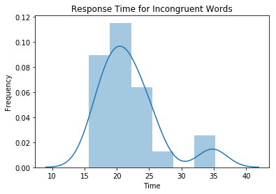

```python
sns.distplot(df['Incongruent']);
plt.xlabel("Time");
plt.ylabel("Frequency");
plt.title("Response Time for Incongruent Words");
```

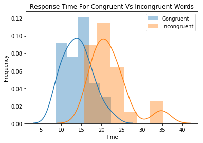

```python
# Compare Both the datasets in graph
sns.distplot(df['Congruent'],label = "Congruent")
sns.distplot(df['Incongruent'],label = "Incongruent")
plt.xlabel("Time");
plt.ylabel("Frequency");
plt.title("Response Time For Congruent Vs Incongruent Words");
plt.legend();
```

(5) Now, perform the statistical test and report your results. What is your confidence level or Type I error associated with your test? What is your conclusion regarding the hypotheses you set up? Did the results match up with your expectations? **Hint:** Think about what is being measured on each individual, and what statistic best captures how an individual reacts in each environment.

> - The Test is two tailed t- test so find the critical value of t at 95% confidance level.
> - Sample Size(n) = 24
> - Degree of freedom(df) = n - 1 = 23

```python
#find t-critical value for 95% confidance interval and 23 degree of freedom for two tailed test

print("t-critical value for two tailed test is: ",round(pt.ppf(0.975,23),4))
```

```
t-critical value for two tailed test is:  2.0687
```

```python
#find the diffenence of each data
df['difference'] = df['Congruent'] - df['Incongruent']
df
```

|  | Congruent | Incongruent | difference |
| --- | --- | --- | --- |
| 0 | 12.079 | 19.278 | -7.199 |
| 1 | 16.791 | 18.741 | -1.950 |
| 2 | 9.564 | 21.214 | -11.650 |
| 3 | 8.630 | 15.687 | -7.057 |
| 4 | 14.669 | 22.803 | -8.134 |
| 5 | 12.238 | 20.878 | -8.640 |
| 6 | 14.692 | 24.572 | -9.880 |
| 7 | 8.987 | 17.394 | -8.407 |
| 8 | 9.401 | 20.762 | -11.361 |
| 9 | 14.480 | 26.282 | -11.802 |
| 10 | 22.328 | 24.524 | -2.196 |
| 11 | 15.298 | 18.644 | -3.346 |
| 12 | 15.073 | 17.510 | -2.437 |
| 13 | 16.929 | 20.330 | -3.401 |
| 14 | 18.200 | 35.255 | -17.055 |
| 15 | 12.130 | 22.158 | -10.028 |
| 16 | 18.495 | 25.139 | -6.644 |
| 17 | 10.639 | 20.429 | -9.790 |
| 18 | 11.344 | 17.425 | -6.081 |
| 19 | 12.369 | 34.288 | -21.919 |
| 20 | 12.944 | 23.894 | -10.950 |
| 21 | 14.233 | 17.960 | -3.727 |
| 22 | 19.710 | 22.058 | -2.348 |
| 23 | 16.004 | 21.157 | -5.153 |

```python
#sd and mean of the differenced dataset
s_std = df['difference'].std()
print("Standard Deviation of the diff sample: ", round(s_std,4))
s_mean = con_mean - incon_mean
print("Mean of Diff: ", round(s_mean,4))
```

```
Standard Deviation of the diff sample:  4.8648
Mean of Diff:  -7.9648
```

let's recap our statistics

- For two tailed t-test at 95% confidence level
- Sample size(n) = 24
- Degree Of Freedom(df) = 23
- t - critical ( $t_{critical}$) = ∓2.069
- Standerd Deviation(SD) = 4.8648
- Mean of difference data (x̄) = -7.9648
- Confidance Interval(CI) at 95% level = (-10.019028, -5.910555)

```python
# Calculate the t-value
t_value = s_mean/(s_std/math.sqrt(24))
print("t-Value is: ",t_value)
```

```
t-Value is:  -8.02070694411
```

> - The calculated t-statistic is -8.0207 for the difference in colour recognition time means of the congruent and incongruent words data. And -8.0207 is much lower than the t-critical value. Since the t-statistic is in the critical region, so the null hypothesis is rejected.
> - Null hypothesis rejected At `α = 0.05`, the time to name colours is significantly different between congruent and incongruent tasks. People do not take the same speed in naming colours when the word’s meaning and its colour match, as when they do not match. The result confirms my expectations.
> - According to the confidence intervals, we can say that the true difference between the congruent and incongruent group mean time is between -10.019028 and -5.910555.

(6) Optional: What do you think is responsible for the effects observed? Can you think of an alternative or similar task that would result in a similar effect? Some research about the problem will be helpful for thinking about these two questions!

> **What is responsible for the effects observed**

> What this reveals is that the brain can’t help but read. As habitual readers, we encounter and comprehend words on such a persistent basis that the reading occurs almost effortlessly, whereas declaration of a color requires more cognitive effort. When there is a conflict between these two sources of information, our cognitive load is increased, and our brains have to work harder to resolve the required difference. Performing these tasks (preventing reading, processing word color, and resolving information conflict) ultimately slows down our responses, and makes the task take longer. There are a few theories that slightly differ in their definitions of the Stroop Effect, yet their differences mostly lie in which part that they emphasize. For example, one theory emphasizes that the automaticity of reading as the principal cause of Stroop interference, while another emphasizes the mental prioritizing which we perform when reading, as compared to defining colors. While differences in theories may therefore exist, all essentially converge on the central premise that reading is a simpler and more automatic task than stating colors, and that a conflict between the two will increase the time needed for processing.

> **The alternative or similar task that would result in a similar effect**

> Termed the [Numerical Stroop Effect](https://www.sciencedirect.com/science/article/pii/0028393279900538), this experiment has shown that presenting numbers of incongruent sizes next to each other will slow down reading and comprehension. For an example, see the image below:

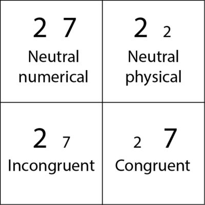

> This experiment shows that, with all else being controlled for, incongruence in numerical size will cause the greatest interference, increasing the delay in comprehension. An interesting feature with the Numerical Stroop is that the interference is [found for both types of incongruence](http://link.springer.com/article/10.3758/BF03202431) – when the numbers are incongruent with size, then a delay is shown for reporting the size, as well as for reporting the numbers. This effect reveals that the automatic processing is not just limited to words, suggesting that the brain looks for normal patterns in a variety of presented stimuli, as it appears to struggle when this doesn’t occur.

**Ref:**

[The Stroop Effect – How it Works and Why](https://imotions.com/blog/the-stroop-effect/)